# CaseStudy

Jonathan Kang

10/30/2021

## Case Study 1

### Describe the dataset and any issues with it.

```r
loans_full_schema <- read.csv("~/Downloads/loans_full_schema.csv")

str(loans_full_schema)
```

```
## 'data.frame':    10000 obs. of  55 variables:
##  $ emp_title                       : chr  "global config engineer " "warehouse office clerk" "assembly" "customer service" ...
##  $ emp_length                      : int  3 10 3 1 10 NA 10 10 10 3 ...
##  $ state                           : chr  "NJ" "HI" "WI" "PA" ...
##  $ homeownership                   : chr  "MORTGAGE" "RENT" "RENT" "RENT" ...
##  $ annual_income                   : num  90000 40000 40000 30000 35000 34000 35000 110000 65000 30000 ...
##  $ verified_income                 : chr  "Verified" "Not Verified" "Source Verified" "Not Verified" ...
##  $ debt_to_income                  : num  18.01 5.04 21.15 10.16 57.96 ...
##  $ annual_income_joint             : num  NA NA NA NA 57000 NA 155000 NA NA NA ...
##  $ verification_income_joint       : chr  "" "" "" "" ...
##  $ debt_to_income_joint            : num  NA NA NA NA 37.7 ...
##  $ delinq_2y                       : int  0 0 0 0 0 1 0 1 1 0 ...
##  $ months_since_last_delinq        : int  38 NA 28 NA NA 3 NA 19 18 NA ...
##  $ earliest_credit_line            : int  2001 1996 2006 2007 2008 1990 2004 2005 1998 2001 ...
##  $ inquiries_last_12m              : int  6 1 4 0 7 6 1 1 3 0 ...
```

[output cut: 41 more lines]

```r
summary(loans_full_schema)
```

```
##   emp_title           emp_length       state           homeownership
##  Length:10000       Min.   : 0.00   Length:10000       Length:10000
##  Class :character   1st Qu.: 2.00   Class :character   Class :character
##  Mode  :character   Median : 6.00   Mode  :character   Mode  :character
##                     Mean   : 5.93
##                     3rd Qu.:10.00
##                     Max.   :10.00
##                     NA's   :817
##  annual_income     verified_income    debt_to_income   annual_income_joint
##  Min.   :      0   Length:10000       Min.   :  0.00   Min.   :  19200
##  1st Qu.:  45000   Class :character   1st Qu.: 11.06   1st Qu.:  86834
##  Median :  65000   Mode  :character   Median : 17.57   Median : 113000
##  Mean   :  79222                      Mean   : 19.31   Mean   : 127915
##  3rd Qu.:  95000                      3rd Qu.: 25.00   3rd Qu.: 151546
##  Max.   :2300000                      Max.   :469.09   Max.   :1100000
##                                       NA's   :24       NA's   :8505
##  verification_income_joint debt_to_income_joint   delinq_2y
##  Length:10000              Min.   : 0.32        Min.   : 0.000
##  Class :character          1st Qu.:14.16        1st Qu.: 0.000
##  Mode  :character          Median :19.72        Median : 0.000
##                            Mean   :19.98        Mean   : 0.216
##                            3rd Qu.:25.50        3rd Qu.: 0.000
##                            Max.   :39.98        Max.   :13.000
##                            NA's   :8505
##  months_since_last_delinq earliest_credit_line inquiries_last_12m
##  Min.   :  1.00           Min.   :1963         Min.   : 0.000
##  1st Qu.: 19.00           1st Qu.:1997         1st Qu.: 0.000
##  Median : 34.00           Median :2003         Median : 1.000
##  Mean   : 36.76           Mean   :2001         Mean   : 1.958
##  3rd Qu.: 53.00           3rd Qu.:2006         3rd Qu.: 3.000
##  Max.   :118.00           Max.   :2015         Max.   :29.000
##  NA's   :5658
##  total_credit_lines open_credit_lines total_credit_limit total_credit_utilized
##  Min.   : 2.00      Min.   : 0.0      Min.   :      0    Min.   :     0
##  1st Qu.:14.00      1st Qu.: 7.0      1st Qu.:  51594    1st Qu.: 19186
##  Median :21.00      Median :10.0      Median : 114667    Median : 36927
##  Mean   :22.68      Mean   :11.4      Mean   : 183606    Mean   : 51049
##  3rd Qu.:29.00      3rd Qu.:14.0      3rd Qu.: 267550    3rd Qu.: 65421
##  Max.   :87.00      Max.   :51.0      Max.   :3386034    Max.   :942456
##
```

[output cut: 81 more lines]

```
##  Length:10000           Length:10000        Min.   :    0   Min.   :    0.0
##  Class :character       Class :character    1st Qu.: 6679   1st Qu.:  928.7
##  Mode  :character       Mode  :character    Median :12380   Median : 1563.3
##                                             Mean   :14459   Mean   : 2494.2
##                                             3rd Qu.:20690   3rd Qu.: 2616.0
##                                             Max.   :40000   Max.   :41630.4
##
##  paid_principal    paid_interest    paid_late_fees
##  Min.   :    0.0   Min.   :   0.0   Min.   : 0.0000
##  1st Qu.:  587.1   1st Qu.: 221.8   1st Qu.: 0.0000
##  Median :  985.0   Median : 446.1   Median : 0.0000
##  Mean   : 1894.5   Mean   : 599.7   Mean   : 0.1195
##  3rd Qu.: 1694.6   3rd Qu.: 825.4   3rd Qu.: 0.0000
##  Max.   :40000.0   Max.   :4216.4   Max.   :52.9800
##
```

This dataset contains information about the loans made in a Lending Club platform, regarding multiple factors such as income, interest rate, and so on. Other than quantitative data, there is also categorical data included in this data, such as loan purpose, status, and others. One large issue with the given dataset is the large amount of NA or empty cells. If we do have to perform data analysis later on, we may need to choose which predictors we will need to use and how we should deal with the NA cells.

### Generate a minimum of 5 unique visualizations using the data and write a brief description of your observations.

All attempts should be made to make the visualizations visually appealing

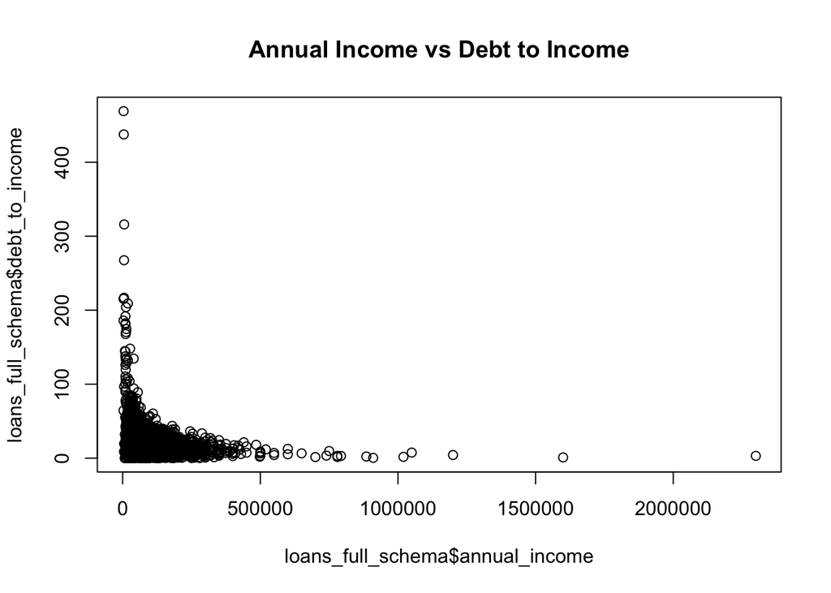

```r
#scatter
plot(loans_full_schema$annual_income, loans_full_schema$debt_to_income, main = "Annual Income vs Debt to Income")
```

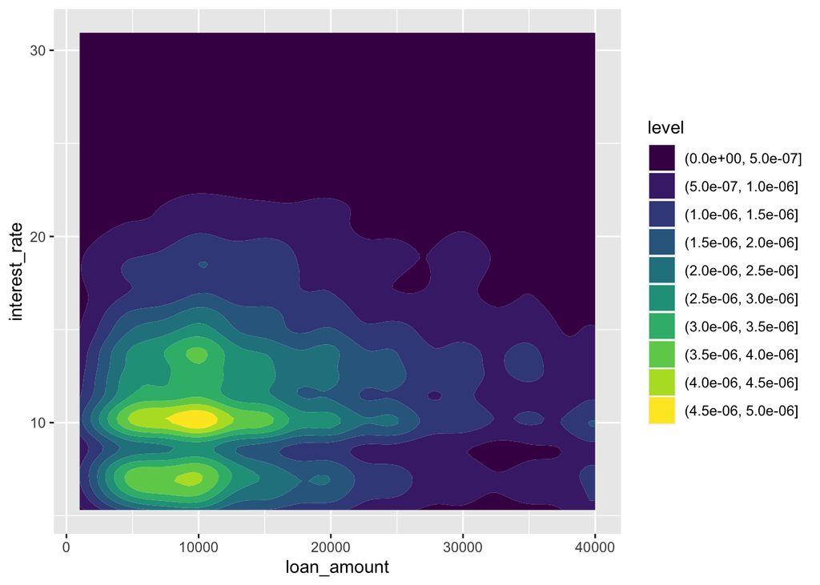

```r
#density
ggplot(loans_full_schema, aes(loan_amount, interest_rate)) + geom_density_2d_filled()
```

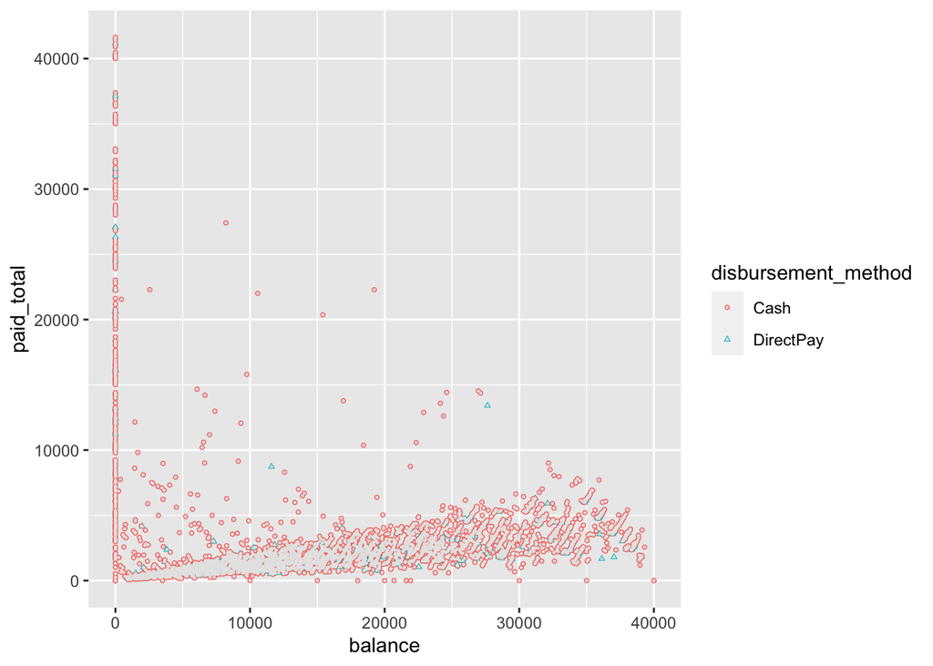

```r
#scatter different shapes
ggplot(loans_full_schema,aes(balance, paid_total, shape = disbursement_method)) +
  geom_point(aes(colour  =  disbursement_method), size  =  1) + geom_point(colour  =  "grey90", size  =  0.5)
```

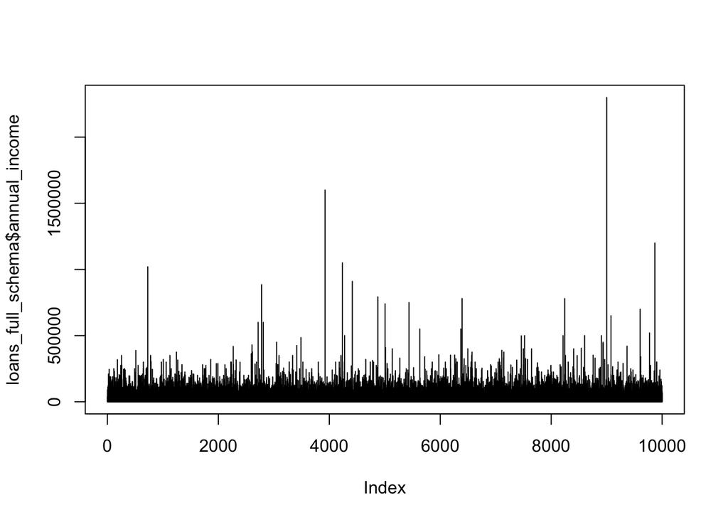

```r
#high density
plot(loans_full_schema$annual_income, type= "h")
```

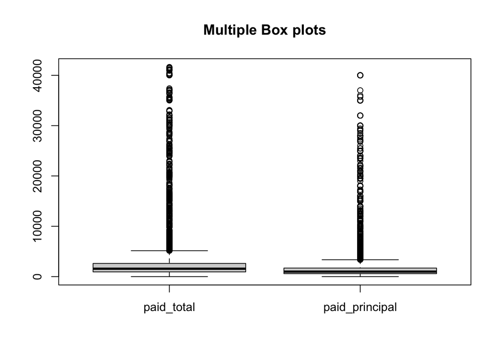

```r
#boxplot
boxplot(loans_full_schema[,52:53], main='Multiple Box plots')
```

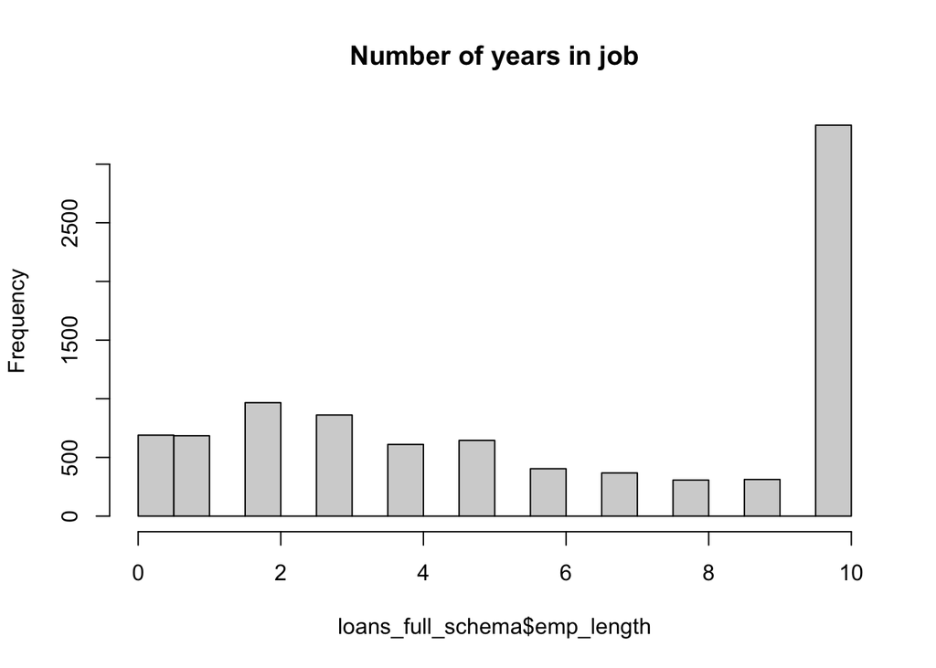

```r
#horizontal plot
hist(loans_full_schema$emp_length, main = "Number of years in job")
```

### Create a feature set and create a model which predicts interest rate using at least 2 algorithms.

Describe any data cleansing that must be performed and analysis when examining the data.

```r
loans_schema <- loans_full_schema %>%
  na.omit() %>%
  mutate(disbursement_method = if_else(disbursement_method == "Cash", 0, 1)) %>%
  mutate(initial_listing_status = if_else(initial_listing_status == "whole", 1, 0)) %>%
  select(-emp_title, -state, -homeownership, -verified_income, -verification_income_joint, -loan_purpose, -application_type, -grade, -sub_grade, -issue_month, -loan_status, -disbursement_method, -initial_listing_status, -current_accounts_delinq, -num_accounts_120d_past_due, -num_accounts_30d_past_due, -public_record_bankrupt, -paid_principal)

loans.full <- lm(interest_rate~., data = loans_schema)

summary(loans.full)
```

```
##
## Call:
## lm(formula = interest_rate ~ ., data = loans_schema)
##
## Residuals:
##     Min      1Q  Median      3Q     Max
## -5.7853 -1.8357 -0.2519  1.4814  9.1056
##
## Coefficients:
##                                    Estimate Std. Error t value Pr(>|t|)
## (Intercept)                      -9.217e+01  6.494e+01  -1.419  0.15766
## emp_length                        6.853e-02  6.183e-02   1.108  0.26932
## annual_income                    -1.141e-05  8.479e-06  -1.345  0.18032
## debt_to_income                   -6.436e-03  9.719e-03  -0.662  0.50878
## annual_income_joint               1.288e-05  6.080e-06   2.118  0.03567 *
## debt_to_income_joint              3.867e-02  3.595e-02   1.076  0.28359
## delinq_2y                        -1.545e-01  2.515e-01  -0.614  0.53988
## months_since_last_delinq         -2.982e-02  1.489e-02  -2.003  0.04684 *
## earliest_credit_line              4.628e-02  3.239e-02   1.429  0.15502
## inquiries_last_12m                6.226e-02  1.027e-01   0.606  0.54513
## total_credit_lines                2.402e-02  4.165e-02   0.577  0.56486
## open_credit_lines                -6.357e-01  2.262e+00  -0.281  0.77899
## total_credit_limit               -1.593e-06  1.465e-06  -1.087  0.27841
## total_credit_utilized            -4.462e-06  5.860e-06  -0.761  0.44748
## num_collections_last_12m          3.176e+00  1.790e+00   1.775  0.07781 .
## num_historical_failed_to_pay     -5.095e-01  7.364e-01  -0.692  0.49003
## months_since_90d_late             1.854e-02  1.320e-02   1.404  0.16205
## total_collection_amount_ever     -3.318e-05  2.000e-04  -0.166  0.86843
## current_installment_accounts     -1.069e-01  4.282e-01  -0.250  0.80321
## accounts_opened_24m               5.531e-02  8.789e-02   0.629  0.53001
## months_since_last_credit_inquiry -1.109e-01  4.419e-02  -2.510  0.01302 *
## num_satisfactory_accounts         7.013e-01  2.239e+00   0.313  0.75448
## num_active_debit_accounts         4.789e-01  2.002e-01   2.392  0.01786 *
## total_debit_limit                -4.913e-05  1.657e-05  -2.966  0.00346 **
## num_total_cc_accounts            -2.585e-02  6.203e-02  -0.417  0.67736
## num_open_cc_accounts             -1.079e-01  4.386e-01  -0.246  0.80604
## num_cc_carrying_balance          -1.034e-01  1.751e-01  -0.590  0.55577
## num_mort_accounts                -3.821e-01  1.779e-01  -2.148  0.03320 *
## account_never_delinq_percent      5.539e-03  2.025e-02   0.274  0.78476
## tax_liens                        -1.446e+00  1.355e+00  -1.067  0.28744
## loan_amount                      -5.578e+02  5.654e+02  -0.987  0.32529
## term                              3.323e-01  3.991e-02   8.327 2.95e-14 ***
## installment                       3.062e-02  3.526e-03   8.686 3.42e-15 ***
## balance                           5.578e+02  5.654e+02   0.987  0.32529
## paid_total                        5.578e+02  5.654e+02   0.987  0.32529
## paid_interest                    -5.578e+02  5.654e+02  -0.987  0.32530
## paid_late_fees                   -5.578e+02  5.654e+02  -0.987  0.32530
## ---
## Signif. codes:  0 '***' 0.001 '**' 0.01 '*' 0.05 '.' 0.1 ' ' 1
##
## Residual standard error: 2.874 on 166 degrees of freedom
## Multiple R-squared:  0.7769, Adjusted R-squared:  0.7285
## F-statistic: 16.06 on 36 and 166 DF,  p-value: < 2.2e-16
```

```r
step(loans.full, direction="both")
```

```
## Start:  AIC=461.81
## interest_rate ~ emp_length + annual_income + debt_to_income +
##     annual_income_joint + debt_to_income_joint + delinq_2y +
##     months_since_last_delinq + earliest_credit_line + inquiries_last_12m +
##     total_credit_lines + open_credit_lines + total_credit_limit +
##     total_credit_utilized + num_collections_last_12m + num_historical_failed_to_pay +
##     months_since_90d_late + total_collection_amount_ever + current_installment_accounts +
##     accounts_opened_24m + months_since_last_credit_inquiry +
##     num_satisfactory_accounts + num_active_debit_accounts + total_debit_limit +
##     num_total_cc_accounts + num_open_cc_accounts + num_cc_carrying_balance +
##     num_mort_accounts + account_never_delinq_percent + tax_liens +
##     loan_amount + term + installment + balance + paid_total +
##     paid_interest + paid_late_fees
##
##                                    Df Sum of Sq    RSS    AIC
## - total_collection_amount_ever      1      0.23 1371.7 459.85
## - num_open_cc_accounts              1      0.50 1371.9 459.89
## - current_installment_accounts      1      0.51 1372.0 459.89
## - account_never_delinq_percent      1      0.62 1372.1 459.90
## - open_credit_lines                 1      0.65 1372.1 459.91
## - num_satisfactory_accounts         1      0.81 1372.2 459.93
## - num_total_cc_accounts             1      1.44 1372.9 460.03
## - total_credit_lines                1      2.75 1374.2 460.22
## - num_cc_carrying_balance           1      2.88 1374.3 460.24
## - inquiries_last_12m                1      3.04 1374.5 460.26
## - delinq_2y                         1      3.12 1374.6 460.27
## - accounts_opened_24m               1      3.27 1374.7 460.30
## - debt_to_income                    1      3.62 1375.1 460.35
## - num_historical_failed_to_pay      1      3.95 1375.4 460.40
## - total_credit_utilized             1      4.79 1376.2 460.52
## - paid_late_fees                    1      8.04 1379.5 461.00
## - paid_interest                     1      8.04 1379.5 461.00
## - paid_total                        1      8.04 1379.5 461.00
## - balance                           1      8.04 1379.5 461.00
## - loan_amount                       1      8.04 1379.5 461.00
## - tax_liens                         1      9.41 1380.8 461.20
## - debt_to_income_joint              1      9.56 1381.0 461.22
## - total_credit_limit                1      9.77 1381.2 461.25
## - emp_length                        1     10.15 1381.6 461.31
## <none>                                          1371.4 461.81
```

[output cut: 935 more lines]

```
## + paid_interest                     1      0.47 1448.4 436.90
## + total_collection_amount_ever      1      0.44 1448.4 436.90
## + accounts_opened_24m               1      0.36 1448.5 436.91
## + current_installment_accounts      1      0.33 1448.5 436.92
## + account_never_delinq_percent      1      0.01 1448.9 436.96
## - earliest_credit_line              1     38.44 1487.3 438.28
## - num_mort_accounts                 1     74.49 1523.4 443.14
## - num_active_debit_accounts         1     75.49 1524.4 443.27
## - months_since_last_credit_inquiry  1     96.81 1545.7 446.09
## - total_debit_limit                 1    105.51 1554.4 447.23
## - paid_total                        1    342.04 1790.9 475.99
## - balance                           1    383.62 1832.5 480.65
## - loan_amount                       1    642.05 2090.9 507.43
## - installment                       1    775.12 2224.0 519.95
## - term                              1    775.23 2224.1 519.96
```

```
##
## Call:
## lm(formula = interest_rate ~ emp_length + annual_income + debt_to_income +
##     annual_income_joint + months_since_last_delinq + earliest_credit_line +
##     num_collections_last_12m + months_since_last_credit_inquiry +
##     num_active_debit_accounts + total_debit_limit + num_mort_accounts +
##     tax_liens + loan_amount + term + installment + balance +
##     paid_total, data = loans_schema)
##
## Coefficients:
##                      (Intercept)                        emp_length
##                       -1.249e+02                         9.966e-02
##                    annual_income                    debt_to_income
##                       -1.392e-05                        -8.600e-03
##              annual_income_joint          months_since_last_delinq
##                        9.341e-06                        -1.344e-02
##             earliest_credit_line          num_collections_last_12m
##                        6.296e-02                         3.003e+00
## months_since_last_credit_inquiry         num_active_debit_accounts
##                       -1.171e-01                         3.633e-01
##                total_debit_limit                 num_mort_accounts
##                       -4.976e-05                        -3.823e-01
##                        tax_liens                       loan_amount
##                       -1.626e+00                        -5.687e-03
##                             term                       installment
##                        3.483e-01                         3.161e-02
##                          balance                        paid_total
##                        4.569e-03                         4.183e-03
```

```r
loans.reduced <- lm(formula = interest_rate ~ emp_length + annual_income + debt_to_income +
    annual_income_joint + months_since_last_delinq + earliest_credit_line +
    num_collections_last_12m + months_since_last_credit_inquiry +
    num_active_debit_accounts + total_debit_limit + num_mort_accounts +
    tax_liens + loan_amount + term + installment + balance +
    paid_total, data = loans_schema)

summary(loans.reduced)
```

```
##
## Call:
## lm(formula = interest_rate ~ emp_length + annual_income + debt_to_income +
##     annual_income_joint + months_since_last_delinq + earliest_credit_line +
##     num_collections_last_12m + months_since_last_credit_inquiry +
##     num_active_debit_accounts + total_debit_limit + num_mort_accounts +
##     tax_liens + loan_amount + term + installment + balance +
##     paid_total, data = loans_schema)
##
## Residuals:
##     Min      1Q  Median      3Q     Max
## -5.6978 -1.9682 -0.1817  1.4804  7.3500
##
## Coefficients:
##                                    Estimate Std. Error t value Pr(>|t|)
## (Intercept)                      -1.249e+02  5.699e+01  -2.192 0.029611 *
## emp_length                        9.966e-02  5.646e-02   1.765 0.079203 .
## annual_income                    -1.392e-05  7.601e-06  -1.831 0.068667 .
## debt_to_income                   -8.600e-03  6.175e-03  -1.393 0.165345
## annual_income_joint               9.341e-06  5.324e-06   1.755 0.080996 .
## months_since_last_delinq         -1.344e-02  9.541e-03  -1.408 0.160729
## earliest_credit_line              6.296e-02  2.842e-02   2.215 0.027959 *
## num_collections_last_12m          3.003e+00  1.680e+00   1.787 0.075510 .
## months_since_last_credit_inquiry -1.171e-01  3.332e-02  -3.516 0.000551 ***
## num_active_debit_accounts         3.633e-01  1.170e-01   3.105 0.002204 **
## total_debit_limit                -4.976e-05  1.356e-05  -3.670 0.000317 ***
## num_mort_accounts                -3.823e-01  1.239e-01  -3.084 0.002355 **
## tax_liens                        -1.626e+00  1.082e+00  -1.502 0.134791
## loan_amount                      -5.687e-03  6.281e-04  -9.054  < 2e-16 ***
## term                              3.483e-01  3.501e-02   9.949  < 2e-16 ***
## installment                       3.161e-02  3.178e-03   9.948  < 2e-16 ***
## balance                           4.569e-03  6.528e-04   6.999 4.60e-11 ***
## paid_total                        4.183e-03  6.330e-04   6.609 4.02e-10 ***
## ---
## Signif. codes:  0 '***' 0.001 '**' 0.01 '*' 0.05 '.' 0.1 ' ' 1
##
## Residual standard error: 2.799 on 185 degrees of freedom
## Multiple R-squared:  0.7643, Adjusted R-squared:  0.7426
## F-statistic: 35.29 on 17 and 185 DF,  p-value: < 2.2e-16
```

```r
anova(loans.reduced, loans.full)
```

```
## Analysis of Variance Table
##
## Model 1: interest_rate ~ emp_length + annual_income + debt_to_income +
##     annual_income_joint + months_since_last_delinq + earliest_credit_line +
##     num_collections_last_12m + months_since_last_credit_inquiry +
##     num_active_debit_accounts + total_debit_limit + num_mort_accounts +
##     tax_liens + loan_amount + term + installment + balance +
##     paid_total
## Model 2: interest_rate ~ emp_length + annual_income + debt_to_income +
##     annual_income_joint + debt_to_income_joint + delinq_2y +
##     months_since_last_delinq + earliest_credit_line + inquiries_last_12m +
##     total_credit_lines + open_credit_lines + total_credit_limit +
##     total_credit_utilized + num_collections_last_12m + num_historical_failed_to_pay +
##     months_since_90d_late + total_collection_amount_ever + current_installment_accounts +
##     accounts_opened_24m + months_since_last_credit_inquiry +
##     num_satisfactory_accounts + num_active_debit_accounts + total_debit_limit +
##     num_total_cc_accounts + num_open_cc_accounts + num_cc_carrying_balance +
##     num_mort_accounts + account_never_delinq_percent + tax_liens +
##     loan_amount + term + installment + balance + paid_total +
##     paid_interest + paid_late_fees
##   Res.Df    RSS Df Sum of Sq      F Pr(>F)
## 1    185 1448.9
## 2    166 1371.4 19     77.43 0.4933 0.9626
```

First, omit all the NA values of the dataset and remove the categorical columns of this data. Next, we will perform a step function for model selection. This utilizes AIC to determine which values can be removed and added to the model. After model selection, we can verify this result using a partial F-test. Since p-value is larger than alpha=0.05, we can say that we lack significant evidence to conclude the reduced model removed significant variables from the full model. This means that our reduced model is a viable model to proceed.

### Visualize the test results and propose enhancements to the model, what would you do if you had more time. Also describe assumptions you made and your approach.

Next, we will proceed with the diagnostics and transformations.

```r
# sample size
n=dim(loans_schema)[1]
p=10

# Compute Leverages
lev=influence(loans.reduced)$hat

# Determine which exceed the 2p/n threshold
newlev = lev[lev>2*p/n]
length(newlev)/n
```

```
## [1] 0.1970443
```

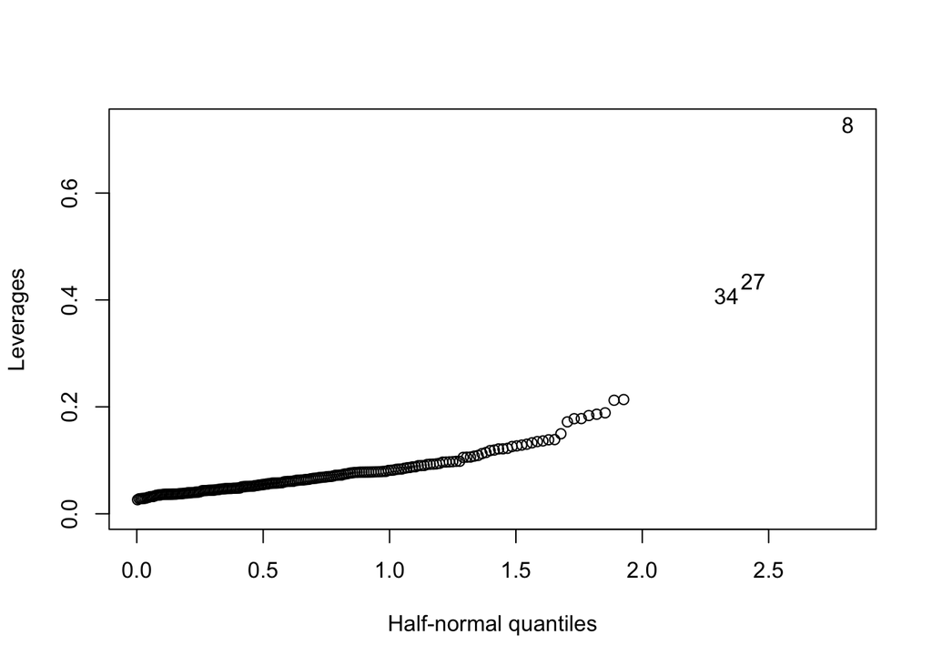

```r
# Half-normal plot
halfnorm(lev, 10, labs=as.character(1:length(newlev)), ylab="Leverages")
```

By the plot, we can conclude that there are some high leverage points. However, these are not bad leverage points. Hence, we do not have any outlying influential points.

```r
# Compute Studentized Residuals
jack=rstudent(loans.reduced);

# The critical value WITH Bonferroni correction is
qt(.05/(2*n), n-p-1)
```

```
## [1] -3.736178
```

```r
# Sort the residuals in descending order to find outliers (if any)
sort(abs(jack), decreasing=TRUE)[1:10]
```

```
##       59      140       83      174      134      116      154       52
## 3.024864 2.710597 2.561531 2.500051 2.373113 2.146894 2.132872 2.122410
##        4      122
## 2.085233 2.008439
```

By calculating the Bonferroni Correction values, we can see that none of the outliers are larger than the absolute value of the Bonferroni correction value.

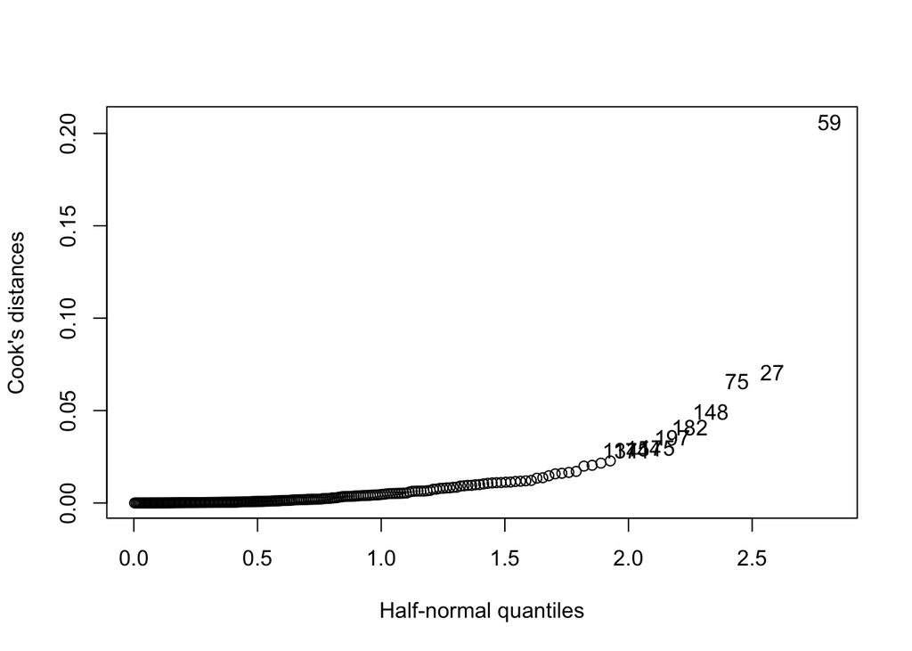

```r
# Compute Cook's Distance
cook = cooks.distance(loans.reduced)

# Prepare a Half Normal Plot of Cook's distances
halfnorm(cook, 10, labs=as.character(1:length(cook)), ylab="Cook's distances")
```

```r
#Use Cook's distance to find any influential points
sum(cooks.distance(loans.reduced) > 1)
```

```
## [1] 0
```

We conclude that there are no influential points according to the Cook’s distance.

So then, we can proceed with checking constant variance and normality assumptions:

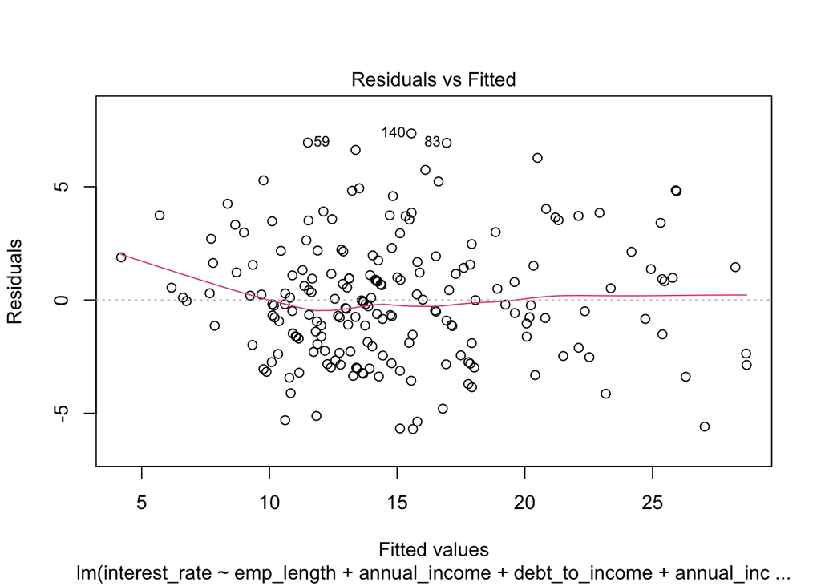

```r
# Checking Constant variance assumption

plot(loans.reduced, which=1)
```

```r
bptest(loans.reduced)
```

```
##
##  studentized Breusch-Pagan test
##
## data:  loans.reduced
## BP = 21.225, df = 17, p-value = 0.2164
```

Both the graphical check and the statistical Breusch-Pagan test indicate that the variance is likely constant. Since our Breusch-Pagan test’s p-value is large, we fail to reject the null. The variance assumption is held in this data

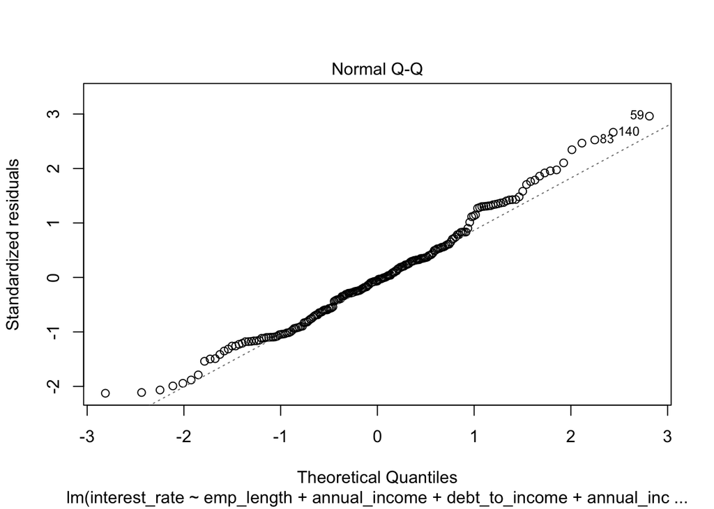

```r
# Check for Normality Assumption

plot(loans.reduced, which=2)
```

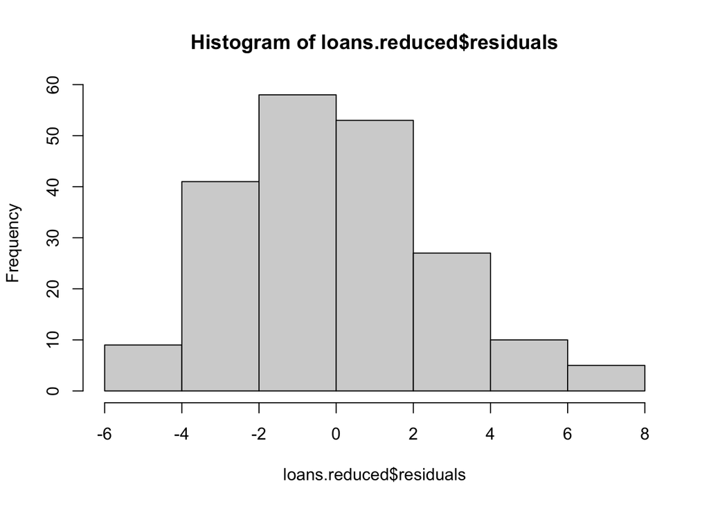

```r
hist(loans.reduced$residuals)
```

```r
ks.test(residuals(loans.reduced), y=pnorm)
```

```
##
##  One-sample Kolmogorov-Smirnov test
##
## data:  residuals(loans.reduced)
## D = 0.24531, p-value = 4.9e-11
## alternative hypothesis: two-sided
```

Both graphical checks and the statistical Kolmogorov-Smirnov test indicate that the normality assumption is violated. (The plot indicates that points are not in a straight line at the edges, and KS test has a significantly low p-value so that we reject the null hypothesis saying that constant normality does not hold).

### Remedial Attempts

```r
loans.transformation = boxcox(loans.reduced, lambda=seq(-2,2, length = 400))
```

[figure not shown]

```r
loans.transformation$x[loans.transformation$y == max(loans.transformation$y)]
```

```
## [1] 0.566416
```

```r
tmp=loans.transformation$x[loans.transformation$y > max(loans.transformation$y) - qchisq(0.95, 1)/2]
range(tmp) #CI for lambda.
```

```
## [1] 0.2957393 0.8270677
```

The optimal value of $\lambda$ is 0.5. For the Box-Cox transformation, $\hat{\lambda}$ is rounded to a nearby value. Since $0.566416$ is the estimated $\hat{\lambda}$ and $1$ and $2$ are not in our confidence interval for $\lambda$, the estimate will be rounded to 0.5.

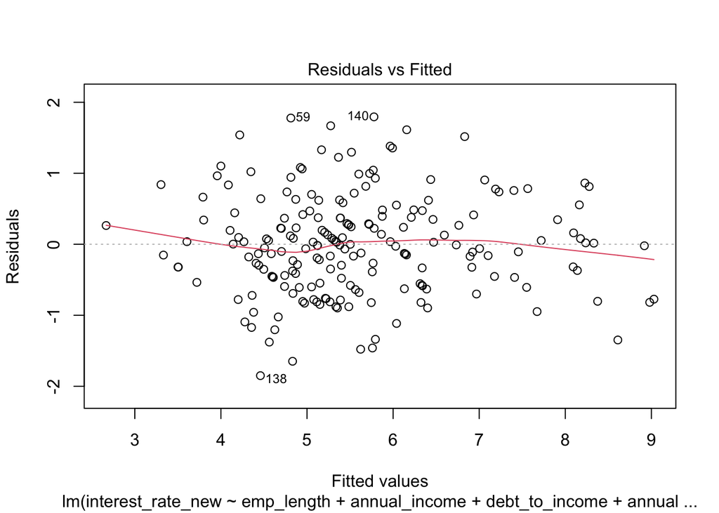

```r
lambda = 0.5

loans_schema_remd <- loans_schema

loans_schema_remd$interest_rate_new = (loans_schema_remd$interest_rate^lambda-1)/lambda

loans.reduced.new <- lm(formula = interest_rate_new ~ emp_length + annual_income + debt_to_income +
    annual_income_joint + months_since_last_delinq + earliest_credit_line +
    num_collections_last_12m + months_since_last_credit_inquiry +
    num_active_debit_accounts + total_debit_limit + num_mort_accounts +
    tax_liens + loan_amount + term + installment + balance +
    paid_total, data = loans_schema_remd)


plot(loans.reduced.new, which=1)
```

```r
bptest(loans.reduced)
```

```
##
##  studentized Breusch-Pagan test
##
## data:  loans.reduced
## BP = 21.225, df = 17, p-value = 0.2164
```

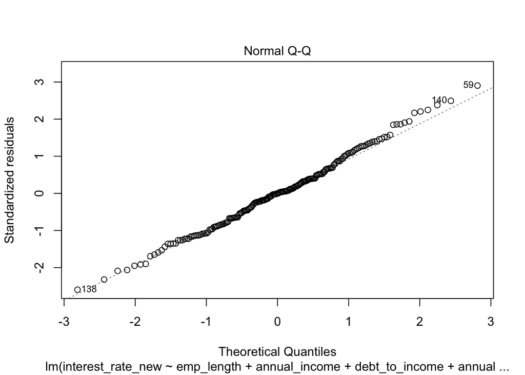

```r
plot(loans.reduced.new, which=2)
```

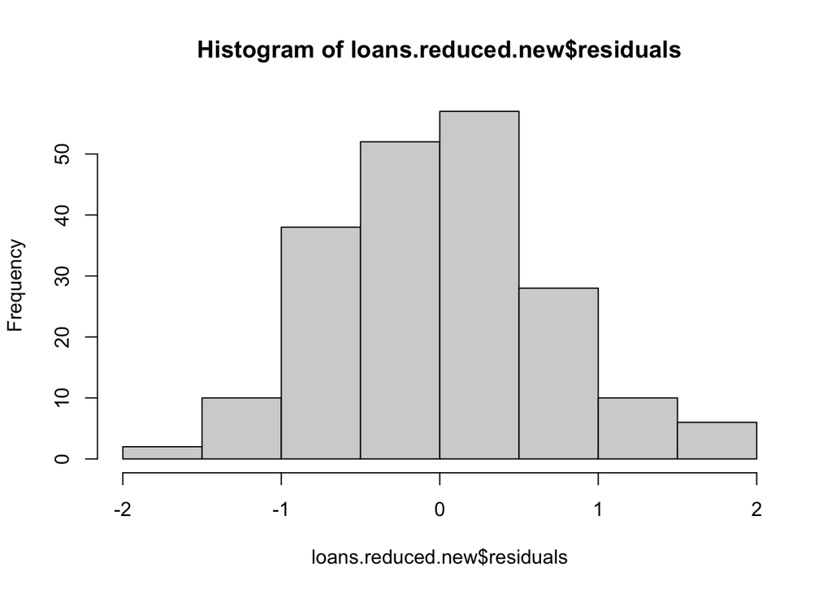

```r
hist(loans.reduced.new$residuals)
```

```r
ks.test(residuals(loans.reduced.new), y=pnorm)
```

```
##
##  One-sample Kolmogorov-Smirnov test
##
## data:  residuals(loans.reduced.new)
## D = 0.11585, p-value = 0.008604
## alternative hypothesis: two-sided
```

Even with the Box-Cox transformation, the normality assumption is still violated. However, the new histogram plot of residuals is now slightly close to a normal distribution, indicating that the transformation has helped reduce the normal violations of model assumptions.

If I had more time, I would attempt on changing and using a different method other than box cox to remedy the violations. Moreover, I would also attempt to incorporate the categorical variables too and try to create a regression model to determine and estimate the interest rates.

# Case Study 2

```r
customer_orders <- read.csv("~/Downloads/casestudy.csv")
colnames(customer_orders) = c("index", "customer_email", "net_revenue", "year")
```

### Total Revenue for each year:

```r
total_revenue_yearly <- customer_orders %>%
  group_by(year) %>%
  mutate(total_revenue = sum(net_revenue)) %>%
  dplyr::select(year, total_revenue) %>%
  unique()

total_revenue_yearly
```

```
## # A tibble: 3 x 2
## # Groups:   year [3]
##    year total_revenue
##   <int>         <dbl>
## 1  2015     29036749.
## 2  2016     25730944.
## 3  2017     31417495.
```

### New Customer Revenue e.g., new customers not present in previous year only

```r
# only show the first instance of each customer
net_rev <- distinct(customer_orders, customer_email, .keep_all = T) %>%
  select(net_revenue)

sum(net_rev)
```

```
## [1] 75958848
```

### Existing Customer Growth. To calculate this, use the Revenue of existing customers for current year –(minus) Revenue of existing customers from the previous year

```r
total_revenue_yearly$total_revenue[2]-total_revenue_yearly$total_revenue[1]
```

```
## [1] -3305806
```

```r
total_revenue_yearly$total_revenue[3]-total_revenue_yearly$total_revenue[2]
```

```
## [1] 5686551
```

**Lost 3305806** from 2015 to 2016; **Earned 5686551** from 2016 to 2017;

### Revenue lost from attrition

```r
# If not misunderstood, revenue lost over the entire time period
total_revenue_yearly$total_revenue[3]-total_revenue_yearly$total_revenue[1]
```

```
## [1] 2380746
```

**2380746** revenue earned over entire time period.

### Existing Customer Revenue Current Year

```r
# check if customer exists previously, then check their revenue of their current year

existing_customers <- duplicated(customer_orders[,2])
existing_customers2 <- customer_orders[existing_customers,]

existing_customers3 <- existing_customers2 %>%
  group_by(year) %>%
  mutate(total_existing_customer_rev = sum(net_revenue)) %>%
  dplyr::select(year, total_existing_customer_rev) %>%
  unique()

existing_customers3
```

```
## # A tibble: 2 x 2
## # Groups:   year [2]
##    year total_existing_customer_rev
##   <int>                       <dbl>
## 1  2016                    7485453.
## 2  2017                    2740887.
```

### Existing Customer Revenue Prior Year

```r
# check if customer exists previously, then check their revenue of their previous year


existing_customers4 <- customer_orders %>%
  arrange(desc(index))

existing_customers5 <- duplicated(existing_customers4[,2])
existing_customers6 <- existing_customers4[existing_customers5,]


existing_customers7 <- existing_customers6 %>%
  arrange(index, descending = T) %>%
  group_by(year) %>%
  mutate(total_existing_customer_rev = sum(net_revenue)) %>%
  dplyr::select(year, total_existing_customer_rev) %>%
  unique()


existing_customers7
```

```
## # A tibble: 2 x 2
## # Groups:   year [2]
##    year total_existing_customer_rev
##   <int>                       <dbl>
## 1  2015                    7560748.
## 2  2016                    2620649.
```

### Total Customers Current Year

```r
total_2017 <- customer_orders %>%
  filter(year == 2017) %>%
  distinct(customer_email, .keep_all = T) %>%
  nrow()

total_2017
```

```
## [1] 249987
```

**249987 Customers** in year 2017

### Total Customers Previous Year

```r
total_2015 <- customer_orders %>%
  filter(year == 2015) %>%
  distinct(customer_email, .keep_all = T) %>%
  nrow()

total_2016 <- customer_orders %>%
  filter(year == 2016) %>%
  distinct(customer_email, .keep_all = T) %>%
  nrow()

c(total_2015, total_2016)
```

```
## [1] 231294 204646
```

**231294 Customers** in year 2015 **204646 Customers** in year 2016

### New Customers

```r
new_2017 <- customer_orders %>%
  filter(year == 2016 | year == 2017)
nrow(customer_orders %>% filter(year==2017)) - nrow(new_2017[duplicated(new_2017[2]),])
```

```
## [1] 229028
```

```r
#total
new_2016 <- customer_orders %>%
  filter(year == 2015 | year == 2016)
nrow(customer_orders %>% filter(year==2016)) - nrow(new_2017[duplicated(new_2016[2]),])
```

```
## [1] 145062
```

There were **229028** new unique customers in 2017 There were **145062** new unique customers in 2016

### Lost Customers

```r
lost_2016 <- customer_orders %>%
  filter(year == 2015 | year == 2016) %>%
  distinct(customer_email, .keep_all = T) %>%
  filter(year == 2015)
nrow(lost_2016)
```

```
## [1] 231294
```

```r
lost_2017 <- customer_orders %>%
  filter(year == 2017 | year == 2016) %>%
  distinct(customer_email, .keep_all = T) %>%
  filter(year == 2017)
nrow(lost_2017)
```

```
## [1] 229028
```

### Unique Observations?

Question: Is there a clear trend for 2015’s net_revenue?

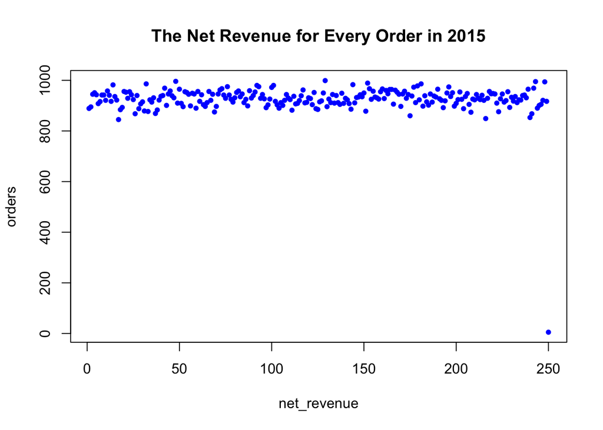

```r
#summary(customer_orders)

net_rev_2015 <- customer_orders %>%
  filter(year == 2015) %>%
  arrange(net_revenue) %>%
  mutate(count = 1) %>%
  dplyr::select(net_revenue, count) %>%
  group_by(net_revenue) %>%
  mutate(sum = sum(count)) %>%
  dplyr::select(-count) %>%
  unique() %>%
  mutate(net_revenue = floor(net_revenue)) %>%
  group_by(net_revenue) %>%
  mutate(orders = sum(sum)) %>%
  dplyr::select(-sum) %>%
  unique()

plot(net_rev_2015, pch = 20, col = "blue", main = "The Net Revenue for Every Order in 2015")
```

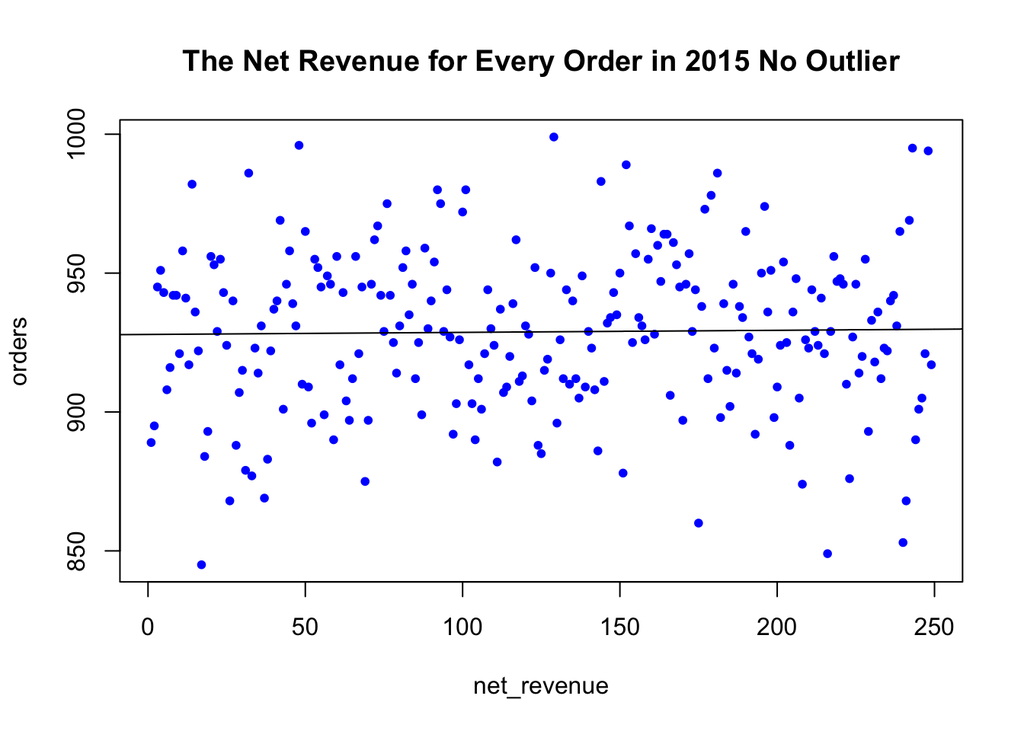

```
## integer(0)
```

```r
net_rev_2015_2 <- net_rev_2015[-nrow(net_rev_2015),]
plot(net_rev_2015_2, pch = 20, col = "blue", main = "The Net Revenue for Every Order in 2015 No Outlier") +
  abline(lm(orders ~ net_revenue, net_rev_2015_2))
```

In my plots above, I am trying to investigate if there are any outstanding points or pattern present in the net revenue for the year of 2015. In the first plot we can see that there is an outlier when the net revenue is 250, disrupting the linear model. Once we remove that value, we can see that the points of the plot are randomly scattered around our linear regression line. We can see that there is no linear trend, that the points are randomly scattered with little to no correlation.